# Data Science 1 Project

May 10, 2019 @ 07:17 AM

## Section 1: Jackpot!

## What *is* the powerball lottery?:

- The numbers available for the white balls were **below *50* from the start until approximately 2001**, **below *60* until 2014**, and became *69* in 2015. The powerball options show the opposite pattern, where they were **above *40* until 2009**, **above *30* until 2014**, and *26* afterwards.
- In 2012, it appears that they added an increased starting jackpot at 40 Million dollars, and they added a 1 Million dollar prize for matching all 5 numbers.

## Dataset:

```
## Observations: 982
## Variables: 12
## $ drawdate          <date> 2019-05-08, 2019-05-04, 2019-05-01, 2019-04-2…
## $ white1            <dbl> 1, 6, 5, 2, 6, 3, 1, 4, 12, 15, 16, 21, 16, 24…
## $ white2            <dbl> 45, 16, 23, 29, 32, 27, 15, 17, 21, 33, 19, 52…
## $ white3            <dbl> 53, 23, 28, 41, 35, 30, 17, 26, 23, 43, 25, 54…
## $ white4            <dbl> 64, 30, 56, 45, 36, 63, 46, 32, 39, 59, 32, 64…
## $ white5            <dbl> 66, 61, 66, 62, 65, 65, 66, 49, 67, 60, 49, 68…
## $ powerball         <dbl> 3, 2, 17, 6, 4, 1, 15, 10, 6, 8, 18, 4, 12, 5,…
## $ drawday           <chr> "WED", "SAT", "WED", "SAT", "WED", "SAT", "WED…
## $ jackpot_value     <dbl> 215, 199, 181, 166, 150, 136, 118, 101, 84, 68…
## $ year              <chr> "2019", "2019", "2019", "2019", "2019", "2019"…
## $ adj_value         <dbl> 1, 1, 1, 1, 1, 1, 1, 1, 1, 1, 1, 1, 1, 1, 1, 1…
## $ jackpot_value_adj <dbl> 215, 199, 181, 166, 150, 136, 118, 101, 84, 68…
```

## Values of the Lottery Over Time: Background

- Objectives
  - Visualize patterns in money won over the years
  - Visualize winning values in 2019 dollars
- Plots
  - Time series to show change
  - Interactive so that you can actually pinpoint specific datapoints
  - Combined so that you can see difference in values (and inflation rate)

## Values of the Lottery Over Time

[interactive chart not shown]

## Fairness and Independence of Winning Numbers: Background

- Objectives
  - Detect patterns in winning numbers
  - Compare the winning numbers over time
- Plots
  - Scatterplots to show basic patterns with time color-coded
  - Density plots for the patterns most easily detected in the scatterplot
  - Combined density plot to show differences between/relationships with the winning numbers for different balls

## Fairness and Independence of Winning Numbers

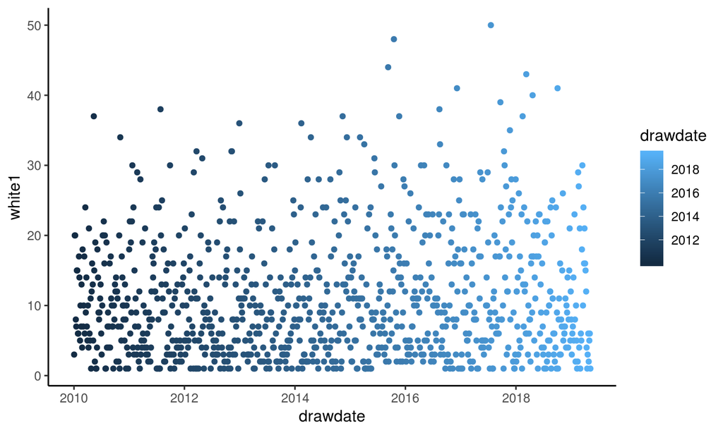

## Fairness and Independence of Winning Numbers

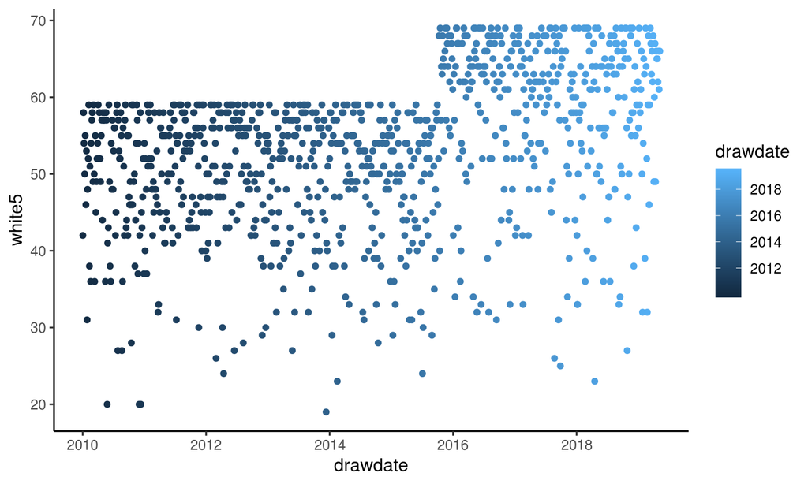

## Fairness and Independence of Winning Numbers

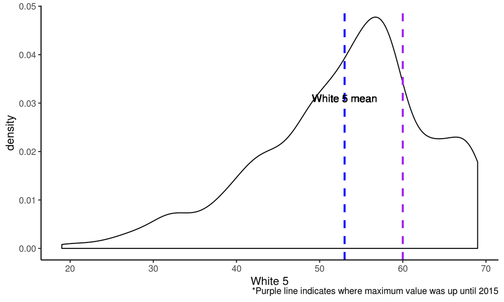

## Fairness and Independence of Winning Numbers

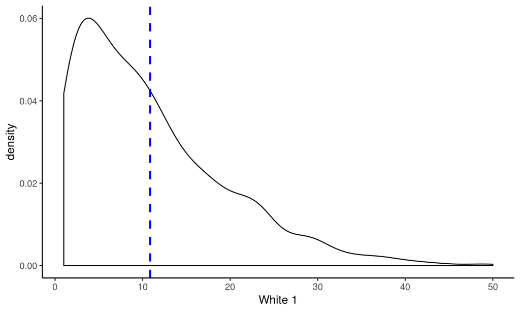

## Fairness and Independence of Winning Numbers

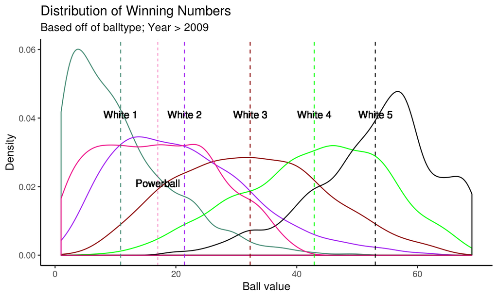

## Fairness and Independence of Winning Numbers

[figure not shown]

## Section 2: Population Ratios

## Background!

For this section we took the population ratios for most of the countries across the world and made them into a consumable format.

## Age ternary plots: Background

- To create these plots, all the data had to come together into one dataframe.

## A look at the population dataframe

```r
glimpse(population)
```

```
## Observations: 4,116
## Variables: 8
## $ country   <chr> "Afghanistan", "Albania", "Algeria", "Angola", "Argent…
## $ year      <chr> "1950", "1950", "1950", "1950", "1950", "1950", "1950"…
## $ pct0to14  <dbl> 42.64327, 38.96211, 40.13023, 41.19633, 30.52883, 33.2…
## $ pct15to59 <dbl> 52.85311, 50.90610, 53.06146, 53.85914, 62.42785, 54.5…
## $ pct60plus <dbl> 4.503620, 10.131796, 6.808316, 4.944525, 7.043321, 12.…
## $ cdr       <dbl> 0.8068261, 0.7653722, 0.7562971, 0.7648903, 0.4890259,…
## $ odr       <dbl> 0.08521012, 0.19902913, 0.12831001, 0.09180475, 0.1128…
## $ tdr       <dbl> 0.8920362, 0.9644013, 0.8846071, 0.8566950, 0.6018493,…
```

## Age ternary plots

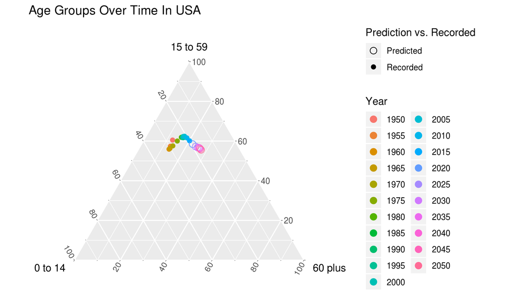

## Age ternary plots

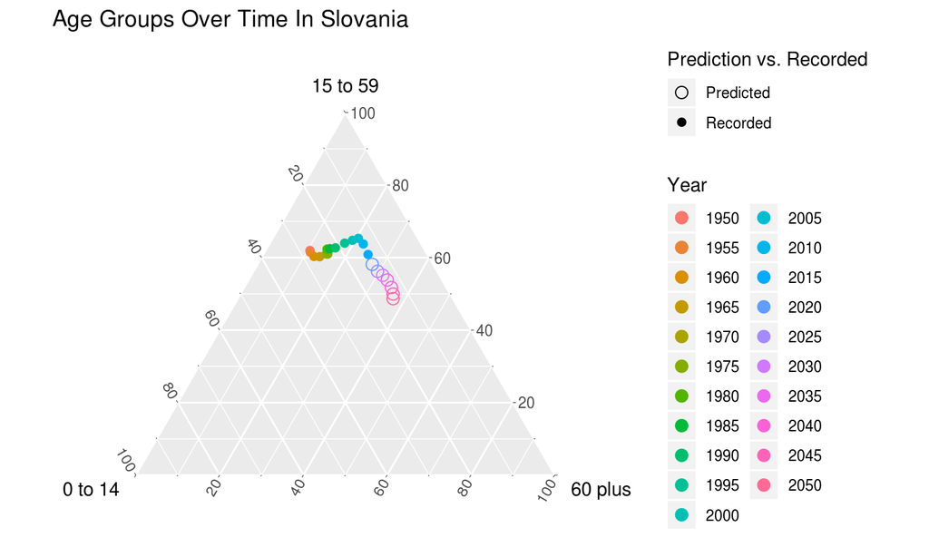

## Dependency Ratios: Background

- For the dependency ratios, we just wanted to look at the predicted year 2020.
- There were a couple places on the original population dataframe that were not really countries, so they were dropped. (Channel Islands; Hong Kong, China; Macao, China; Netherlands Antilles; West Bank and Gaza)
- You will also find a very obvious missing country on the maps and that is because South Sudan was not founded until 2011

## Dependency Ratios:

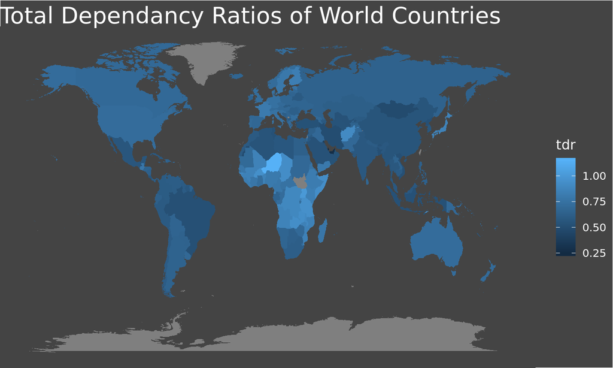

## Dependency Ratios:

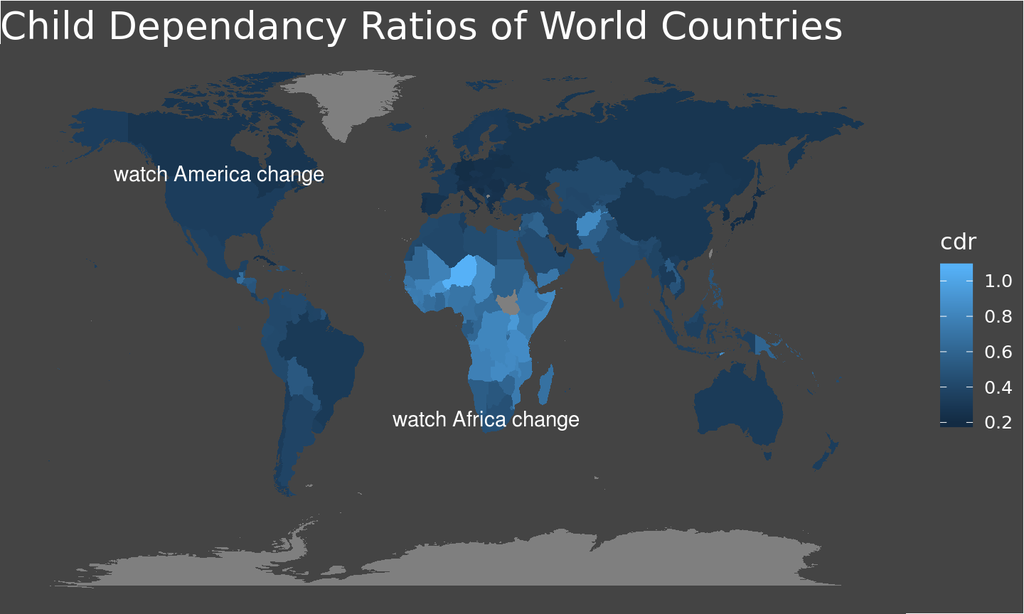

## Dependency Ratios:

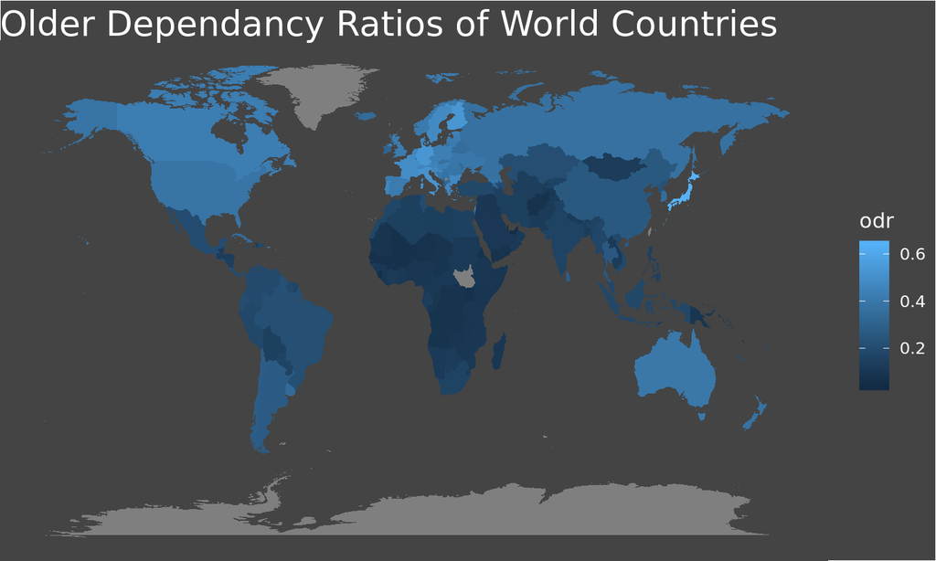